# HW04: RDD and Diff-in-Diff (due 26th October)

In this homework you will investigate the causal effect in two different settings, applying different **identification strategies**, You will also reflect and investigate the identification assumptions that allow for a causal interpretation.

## Regression Discontinuity Design

In this first part you will use data on mayors from municipalities in Brazil to invesitgate th effect of electoral accountability on corruption. The goal is to estimate the effect of being eligible for reelection (having reelection incentives) on misappropriation of resources exploiting random audits on municipalities before the elections. In Brazil there is a two mandate limit for mayors, implying that only mayors in the first mandate can be reelected. The reference paper is [Ferraz and Finan (2011)](https://www.aeaweb.org/articles?id=10.1257/aer.101.4.1274).

```python
from rdrobust import rdrobust, rdbwselect, rdplot
import pandas as pd
import warnings
warnings.filterwarnings('ignore', category=FutureWarning)
warnings.filterwarnings('ignore', category=DeprecationWarning)
warnings.filterwarnings = lambda *a, **kw: None
```

```python
df = pd.read_stata('HW04_data_rdd.dta')
```

```python
df_labels = pd.read_stata('HW04_data_rdd.dta', iterator=True).variable_labels()
df_labels
```

```
{'uf': 'state',
 'nsorteio': 'Número do sorteio',
 'totrecursos': 'Total de recurso fiscalizado no municipio',
 'tot_os': 'Total de OS fiscalizadas no municipio',
 'pop': 'População no ano de 2000',
 'purb': 'Proporção da população urbana no ano de 2000',
 'p_secundario': 'Proporção da população com 18 anos ou mais com secundario completo',
 'cod_ibge6': 'cod_ibge6',
 'pib_capita_02': 'PIB per capita deflacionado em reais de 2001',
 'op_01_04': 'Dummy se o munic teve orçamento participativo no periodo',
 'reeleito': 'Dummy de reeleição',
 'ENEP2000': '2000 ENEP',
 'ENLP2000': '2000 ENLP',
 'pref_idade_tse': 'Idade do prefeito',
 'comarca': 'Sede de Comarca',
 'reeleito_2004': 'Dummy dos candidatos que se reelegeram na eleição de 2004',
 'p_cad_pref': 'Proporção de vereadores eleitos do mesmo partido do prefeito',
 'rec_transf_correntes': '(mean) rec_transf_correntes',
 'gini_ipea': '',
 'fiscalizacoes': 'Total ordens de serviço dada pela planilha CGU',
 'valor_fiscalizado': 'Total ordens de serviço dada pela planilha CGU',
 'incumbent': '(sum) incumbent',
 'vereador9600': '',
 'pmismanagement': '',
 'elected1': '',
 'first': '',
 'lpib02': '',
 'lpop': '',
 'pref_masc': '',
 'pref_escola': '',
 'media2': '',
 'vereador_eleit': '',
 'mun_novo': '',
 'exp_prefeito': '',
 'samepartygov98': '',
 'lrec_trans': '',
 'lfunc_ativ': '',
 'lrec_fisc': '',
 'ncorrupt': '',
 'valor_corrupt': '',
 'pcorrupt': '',
 'dcorrupt': '',
 'esample2': '',
 'wm': 'vote margin',
 'winning_margin': 'running variable',
 'party': 'party affiliation'}
```

```python
df = df[df['esample2']==1]
df.head()
```

|  | uf | nsorteio | totrecursos | tot_os | pop | purb | p_secundario | cod_ibge6 | pib_capita_02 | op_01_04 | ... | lfunc_ativ | lrec_fisc | ncorrupt | valor_corrupt | pcorrupt | dcorrupt | esample2 | wm | winning_margin | party |
| --- | --- | --- | --- | --- | --- | --- | --- | --- | --- | --- | --- | --- | --- | --- | --- | --- | --- | --- | --- | --- | --- |
| 0 | RO | 5 | 6913597.38 | 47.0 | 18207 | 0.815401 | 0.248250 | 566128.0 | 3548.000977 | 0 | ... | 6.167517 | 15.749001 | 3.0 | 672785.125 | 0.097313 | 1.0 | 1.0 | 0.030935 | -0.030935 | 16 |
| 1 | RO | 7 | 7135210.78 | 62.0 | 10459 | 0.198203 | 0.110925 | 566130.0 | 4203.421875 | 0 | ... | 5.641907 | 15.780552 | 0.0 | 0.000 | 0.000000 | 0.0 | 1.0 | 0.172863 | 0.172863 | 3 |
| 2 | RO | 2 | 26821074.06 | 140.0 | 40884 | 0.649178 | 0.254702 | 566138.0 | 3904.267334 | 0 | ... | 6.872128 | 17.104698 | 1.0 | 0.000 | 0.000000 | 1.0 | 1.0 | 0.310956 | 0.310956 | 18 |
| 3 | RO | 4 | 14710780.70 | 89.0 | 47382 | 0.726457 | 0.267212 | 566151.0 | 4081.257812 | 0 | ... | 6.979145 | 16.504091 | 0.0 | 0.000 | 0.000000 | 0.0 | 1.0 | 0.391912 | 0.391912 | 18 |
| 4 | RO | 3 | 4181534.83 | NaN | 23874 | 0.271257 | 0.134546 | 566155.0 | 2192.473633 | 1 | ... | 6.118097 | 15.246189 | 0.0 | 0.000 | 0.000000 | 0.0 | 1.0 | 0.186155 | 0.186155 | 14 |

5 rows × 46 columns

The main outcome of interest is *pcorrupt*, namely, the share of audited resources found that involve corruption (a measure of misappropriation). The explanatory variable is *first*, a dummy variable indicating whether the mayor is in his first mandate. The regression of interest is the following:

$pcorrupt_i = \beta_0 + \beta_1 first_i + \varepsilon_i$

```python
## run the regression above using robust standard errors
import statsmodels.formula.api as smf
from statsmodels.iolib.summary2 import summary_col


ols1 = smf.ols('pcorrupt ~ first', data=df).fit(cov_type='HC1')
```

**What could be some sources of bias, namely, variables that act as confounder?**

An example of confounder could be mayor experience. Indeed, less experienced mayors, more likely to be in their first mandate, may be also more likely to be involed in corruption activities because of their lack of experience.

```python
## run the regression above adding the variables that may act as a confounder
ols2 = smf.ols('pcorrupt ~ first + C(party) + lpop + purb + p_secundario + mun_novo + gini_ipea', df).fit(cov_type='HC1')
```

```python
## display the results
print(summary_col([ols1, ols2], float_format='%0.3f',  info_dict={'N':lambda x: "{0:d}".format(int(x.nobs))}, regressor_order=['Intercept','first']))
```

```
=====================================
               pcorrupt I pcorrupt II
-------------------------------------
Intercept      0.074      0.152
               (0.007)    (0.068)
first          -0.019     -0.019
               (0.009)    (0.010)
C(party)[T.10]            -0.001
                          (0.021)
C(party)[T.5]             0.030
                          (0.022)
p_secundario              -0.141
                          (0.063)
mun_novo                  -0.002
                          (0.015)
lpop                      -0.006
                          (0.006)
gini_ipea                 -0.090
                          (0.077)
C(party)[T.9]             0.047
                          (0.032)
C(party)[T.8]             0.073
                          (0.035)
C(party)[T.7]             0.215
                          (0.014)
C(party)[T.11]            0.017
                          (0.014)
C(party)[T.6]             0.051
                          (0.016)
C(party)[T.4]             0.034
                          (0.021)
C(party)[T.3]             0.022
                          (0.016)
C(party)[T.2]             0.065
                          (0.025)
C(party)[T.18]            0.030
                          (0.016)
C(party)[T.17]            0.058
                          (0.016)
C(party)[T.16]            0.031
                          (0.031)
C(party)[T.15]            0.287
                          (0.015)
C(party)[T.14]            -0.011
                          (0.013)
C(party)[T.13]            -0.016
                          (0.012)
C(party)[T.12]            0.080
                          (0.056)
purb                      0.059
                          (0.029)
R-squared      0.008      0.076
R-squared Adj. 0.006      0.029
N              476        476
=====================================
Standard errors in parentheses.
```

**In your opinion, are there any additional sources of bias that threatens the causal interpretation of the results?**

Unobserved characteristics of first (or second) mandate mayors that affect corruption incentives.

To make sure that this is not the case we will use a regression discontinuity design where the running variable is the margin by which the incumbent won or lost in the previous election. Namely, we compare municipalities where incumbents won or lost by a narrow margin. This comparison provides quasi-random assignment of first-term and second-term mayors across these competitive elections.

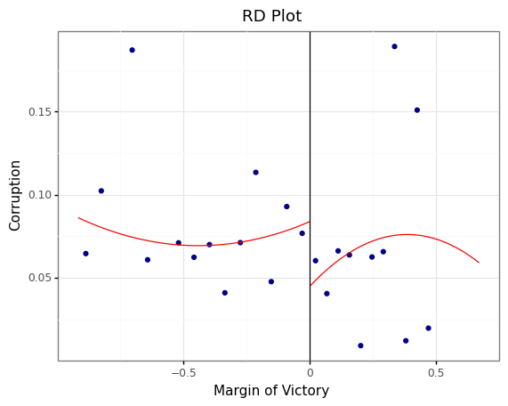

```
Call: rdplot
Number of Observations:                   328
Kernel:                               Uniform
Polynomial Order Est. (p):                  2

                                Left      Right
------------------------------------------------
Number of Observations           200        128
Number of Effective Obs          200        128
Bandwith poly. fit (h)         0.918      0.671
Number of bins scale               1          1
Bins Selected                     15         15
Average Bin Length             0.061      0.045
Median Bin Length              0.061      0.045
IMSE-optimal bins                3.0        5.0
Mimicking Variance bins         11.0       15.0

Relative to IMSE-optimal:
Implied scale                    5.0        3.0
WIMSE variance weight          0.008      0.036
WIMSE bias weight              0.992      0.964
```

```python
## plot the RD plot using as running variable the variable winning_margin
## use a second order polynomial and 15 bins at each side


## NOTE THAT HERE I USE MINUS THE WINNING MARGIN AS A RUNNING VARIABLE TO GET THE SAME COEFFICIENT SIGN AS ABOVE

margin = -df.dropna(subset=['winning_margin']).winning_margin
corruption = df.dropna(subset=['winning_margin']).pcorrupt
rdplot(y=corruption, x=margin,p=2, nbins=15,
         title="RD Plot",
         y_label="Corruption",
         x_label="Margin of Victory")
```

```python
## run the RD regression using the same dependent and explanatory variable as before
## include 4th degree polynomial and the covariates that you included above
party_dummies = pd.get_dummies(df.dropna(subset=['winning_margin'])['party'])
covs = pd.concat([df.dropna(subset=['winning_margin'])[['lpop', 'purb', 'p_secundario', 'mun_novo', 'gini_ipea']], party_dummies], axis=1)
print(rdrobust(y=corruption, x=margin, covs=covs, p=4, vce='hc1'))
```

```
Call: rdrobust
Number of Observations:                   328
Polynomial Order Est. (p):                  4
Polynomial Order Bias (q):                  5
Kernel:                            Triangular
Bandwidth Selection:                    mserd
Var-Cov Estimator:                        HC1

                                Left      Right
------------------------------------------------
Number of Observations           200        128
Number of Unique Obs.            200        127
Number of Effective Obs.         120         96
Bandwidth Estimation           0.199      0.199
Bandwidth Bias                 0.253      0.253
rho (h/b)                      0.784      0.784

Method             Coef.     S.E.   t-stat    P>|t|       95% CI
-------------------------------------------------------------------------
Conventional       -0.02    0.051     -0.4   6.893e-01    [-0.119, 0.079]
Robust                 -        -   -0.558   5.769e-01    [-0.136, 0.076]
```

**Interpret the coefficient:** On average, first term mayors misappropriate 2 percentage point less of resources with respect to incumbent mayors, meaning that having electoral incentives decreases the likelyhood of misappropriation. Note that here the coefficient is not statistically significant because I include only a subset of covariates, while in the paper they include almost all of them.

## Difference-in-Differences

In this part you will use data from Argentina to investigate the causal effect of police on crime. Following the paper by [Di Tella and Schargrodsky (2004)](https://www.aeaweb.org/articles?id=10.1257/000282804322970733), you will exploit the follow-up of a terrorist attack to the Jewish center in Buenos Aires in July 1994, after which all Jewish institution received police protection. This event induced a geographical allocation of police forces orthogonal to a crime regression allowing to isolate the causal effect of having more police in a neighborhood on a proxy for crime (car thefts), through a difference-in-differences analysis.

```python
df = pd.read_stata('HW04_data_DiD.dta')
df_labels = pd.read_stata('HW04_data_DiD.dta', iterator=True).variable_labels()
df_labels
```

```
{'observ': 'block id',
 'barrio': 'neighborhood',
 'calle': 'street',
 'altura': 'street numbering',
 'institu1': 'dummy Jewish institution in the block',
 'institu3': 'dummy Jewish institution one block away',
 'distanci': 'block distance to closest institution',
 'edpub': 'dummy public building/embassy',
 'estserv': 'dummy gas station',
 'banco': 'dummy bank',
 'totrob': 'car theft',
 'mes': 'month',
 'inst3_1': '',
 'month5': '',
 'post': '',
 'inst1p': '',
 'inst3_1p': ''}
```

```python
df.head()
```

|  | observ | barrio | calle | altura | institu1 | institu3 | distanci | edpub | estserv | banco | totrob | mes | inst3_1 | month5 | post | inst1p | inst3_1p |
| --- | --- | --- | --- | --- | --- | --- | --- | --- | --- | --- | --- | --- | --- | --- | --- | --- | --- |
| 0 | 870.0 | Once | Cordoba | a2300 | 0.0 | 1.0 | 1.0 | 1.0 | 0.0 | 0.0 | 0.0 | 4.0 | 1.0 | 0.0 | 0.0 | 0.0 | 0.0 |
| 1 | 851.0 | Once | Tucuman | a2400 | 0.0 | 0.0 | 2.0 | 0.0 | 0.0 | 0.0 | 0.0 | 4.0 | 0.0 | 0.0 | 0.0 | 0.0 | 0.0 |
| 2 | 843.0 | Once | Lavalle | a2300 | 1.0 | 1.0 | 0.0 | 0.0 | 0.0 | 1.0 | 0.0 | 4.0 | 0.0 | 0.0 | 0.0 | 0.0 | 0.0 |
| 3 | 796.0 | Once | Pasteur | a500 | 0.0 | 1.0 | 1.0 | 0.0 | 0.0 | 0.0 | 0.0 | 4.0 | 1.0 | 0.0 | 0.0 | 0.0 | 0.0 |
| 4 | 790.0 | Once | Azcuenaga | a700 | 1.0 | 1.0 | 0.0 | 0.0 | 0.0 | 0.0 | 0.0 | 4.0 | 0.0 | 0.0 | 0.0 | 0.0 | 0.0 |

The main outcome of interest is *totrob*, the total number of car thefts (proxy for criminal activity). The main explanatory variable is a dummy variable indicating whether the there is a Jewish institution in the neighborhood **and** the observation is after July (*inst1p*). The main regression is the following:

$totrob_i = \beta_0 + \beta_1 inst1p_i + \varepsilon_i$

```python
## Run the regression above with robust standard errors
import statsmodels.formula.api as smf

ols1 = smf.ols('totrob ~ inst1p', data=df).fit(cov_type='HC1')
```

**Why this estimate CANNOT be interpreted as causal?**

Blocks with a Jewish institution could display less crime even before the terrorist attacks, for any reason.

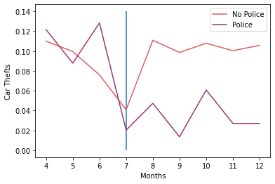

```python
## Plot the time series of car thefts separately for blocks with and without a jewish institutions
## Add a vertical line indicating the terrorist attack
import seaborn as sns
import matplotlib.pyplot as plt

palette = sns.color_palette("flare", 2)
plot = sns.lineplot(data=df, x='mes', y='totrob', hue='institu1', palette=palette, ci=None)
plot.set(xlabel='Months', ylabel='Car Thefts')
plot.legend_.set_title('')
new_labels = ['No Police', 'Police']
for t, l in zip(plot.legend_.texts, new_labels):
    t.set_text(l)
plt.vlines(7, 0, 0.14)
plt.show()
```

**Does the parallel trend assumption hold?**

It does, however, in the graph it is not that evident. In the paper, they test this by running a regression of car thefts on a dummy for a Jewish institution in the period *before* the attack and find no statistically significant difference between different neihborhood, suggesting that the parallel trends assumption holds.

```python
##Run the regression above including month and block fixed effects
from linearmodels import PanelOLS
df_did = df.set_index(['observ', 'mes'])
did = PanelOLS(df_did.totrob, df_did.inst1p, entity_effects=True, time_effects=True).fit(cov_type = 'clustered', cluster_entity=True)
```

```python
##show the results from both regressions
ols1.summary()
```

OLS Regression Results

| Dep. Variable: | totrob | R-squared: | 0.001 |
| --- | --- | --- | --- |
| Model: | OLS | Adj. R-squared: | 0.001 |
| Method: | Least Squares | F-statistic: | 32.75 |
| Date: | Fri, 29 Oct 2021 | Prob (F-statistic): | 1.09e-08 |
| Time: | 11:56:39 | Log-Likelihood: | 4.5306 |
| No. Observations: | 7884 | AIC: | -5.061 |
| Df Residuals: | 7882 | BIC: | 8.884 |
| Df Model: | 1 |  |  |
| Covariance Type: | HC1 |  |  |

|  | coef | std err | z | P>\|z\| | [0.025 | 0.975] |
| --- | --- | --- | --- | --- | --- | --- |
| Intercept | 0.0943 | 0.003 | 33.943 | 0.000 | 0.089 | 0.100 |
| inst1p | -0.0592 | 0.010 | -5.723 | 0.000 | -0.079 | -0.039 |

| Omnibus: | 5778.589 | Durbin-Watson: | 1.891 |
| --- | --- | --- | --- |
| Prob(Omnibus): | 0.000 | Jarque-Bera (JB): | 81436.831 |
| Skew: | 3.518 | Prob(JB): | 0.00 |
| Kurtosis: | 17.085 | Cond. No. | 6.61 |

Notes:  
[1] Standard Errors are heteroscedasticity robust (HC1)

```python
did
```

PanelOLS Estimation Summary

| Dep. Variable: | totrob | R-squared: | 0.0013 |
| --- | --- | --- | --- |
| Estimator: | PanelOLS | R-squared (Between): | -0.0149 |
| No. Observations: | 7884 | R-squared (Within): | 0.0005 |
| Date: | Fri, Oct 29 2021 | R-squared (Overall): | -0.0040 |
| Time: | 11:56:39 | Log-likelihood | 870.52 |
| Cov. Estimator: | Clustered |  |  |
|  |  | F-statistic: | 8.9506 |
| Entities: | 876 | P-value | 0.0028 |
| Avg Obs: | 9.0000 | Distribution: | F(1,6999) |
| Min Obs: | 9.0000 |  |  |
| Max Obs: | 9.0000 | F-statistic (robust): | 9.6788 |
|  |  | P-value | 0.0019 |
| Time periods: | 9 | Distribution: | F(1,6999) |
| Avg Obs: | 876.00 |  |  |
| Min Obs: | 876.00 |  |  |
| Max Obs: | 876.00 |  |  |

Parameter Estimates

|  | Parameter | Std. Err. | T-stat | P-value | Lower CI | Upper CI |
| --- | --- | --- | --- | --- | --- | --- |
| inst1p | -0.0775 | 0.0249 | -3.1111 | 0.0019 | -0.1264 | -0.0287 |

F-test for Poolability: 1.9474  
P-value: 0.0000  
Distribution: F(883,6999)  
Included effects: Entity, Time  
id: 0x7f60bbc68610

**Compare and interpret the coefficients**

The coefficient from the diff-in-diff is larger in magnitude, implying that there are some pre-determined differences between blocks or the two periods that lead to a downward bias of the estimate. The coefficient from the diff-in-diff implies that on average, blocks with a Jewish institution after the terrorist attack display 0.0775 less car thefts than blocks with no Jewish institution before the attack.

This number may not seem meaningful by itself, so what it is often done in empirical analysis is to assess the magnitude looking at the average value of the dependent variable. In this case, the post-attack average number of monthly car thefts is 0.108. Therefore, we can interpret the coefficient as a 70% decrease in crime due to higher police presence, with respect to the average crime level in that period.